# Lung Cancer Data Exploratory Analysis

**Team Members**: Jasmine, Vasant, Chenglang

# Introduction

# Dataset and Motivation

Currently, there are more than 100 types of cancers around the world. Of all, lung cancer has been the first and most diagnosed cancer. It became a threat to public health worldwide. By 2020, there were nearly 2 million cases related to lung cancer deaths. (Tesfaw et al.). While screenings such as low-dose computed tomography can significantly reduce lung cancer mortality, access to these screenings remains unevenly distributed and often limited, especially for vulnerable populations. The barriers to screening include a lack of awareness about risk factors, financial constraints, and geographic limitations. Previous studies have shown that lung cancer outcomes are linked to comorbid conditions (e.g., hypertension, diabetes), as well as behavioral and environmental factors. Although disparities in cancer outcomes have been widely studied, there is limited literature examining how these disparities have evolved over time.

Our dataset includes these varaibles: year of observation, state, sex, age group, race, and the mortality rate (deaths per 100,000 residents). By analyzing these variables, we can track how lung cancer mortality has changed over time in the US, compare rates between men and women, examine differences among racial and age groups, and identify geographic patterns across states. This not only enable us to explore the national trends, but also disparities that may exist between different populations and regions, which ultimately helps inform targeted population and suggests public health strategies or interventions.

In summary, with the variables in our current dataset, we aim to address the following questions: 1. How have lung cancer mortality rates changed nationally over the past two decades? 2. What disparities exist across sex, age, and race? 3. How have these disparities shifted over time?

# Package Set Up

```r
library(tidyverse)
library(janitor)
library(skimr)
library(GGally)
```

# Forming our Dataset

```r
# Combining all yearly CSV files together (all csv file have the exact same data structure, varied by year)
male_files <- list.files("data/male", pattern = "\\.csv$", full.names = TRUE, ignore.case = TRUE)
female_files <- list.files("data/female", pattern = "\\.csv$", full.names = TRUE, ignore.case = TRUE)

male_data <- male_files %>%
  map_dfr(~ read_csv(.x) %>% clean_names()) %>%
  mutate(sex_name = "Male")

female_data <- female_files %>%
  map_dfr(~ read_csv(.x) %>% clean_names()) %>%
  mutate(sex_name = "Female")

lung_cancer_df <- bind_rows(male_data, female_data)
```

# Quick Overview

```r
glimpse(lung_cancer_df)
```

```
## Rows: 16,178,400
## Columns: 19
## $ measure_id    <dbl> 1, 1, 1, 1, 1, 1, 1, 1, 1, 1, 1, 1, 1, 1, 1, 1, 1, 1, 1,…
## $ measure_name  <chr> "Deaths", "Deaths", "Deaths", "Deaths", "Deaths", "Death…
## $ location_id   <dbl> 102, 102, 102, 102, 102, 102, 102, 102, 102, 102, 102, 1…
## $ location_name <chr> "United States of America", "United States of America", …
## $ fips          <dbl> NA, NA, NA, NA, NA, NA, NA, NA, NA, NA, NA, NA, NA, NA, …
## $ race_id       <dbl> 1, 2, 4, 5, 6, 7, 1, 2, 4, 5, 6, 7, 1, 2, 4, 5, 6, 7, 1,…
## $ race_name     <chr> "Total", "Latino", "Black", "White", "AIAN", "Asian", "T…
## $ sex_id        <dbl> 1, 1, 1, 1, 1, 1, 1, 1, 1, 1, 1, 1, 1, 1, 1, 1, 1, 1, 1,…
## $ sex_name      <chr> "Male", "Male", "Male", "Male", "Male", "Male", "Male", …
## $ age_group_id  <dbl> 28, 28, 28, 28, 28, 28, 5, 5, 5, 5, 5, 5, 6, 6, 6, 6, 6,…
## $ age_name      <chr> "<1 year", "<1 year", "<1 year", "<1 year", "<1 year", "…
## $ cause_id      <dbl> 426, 426, 426, 426, 426, 426, 426, 426, 426, 426, 426, 4…
## $ cause_name    <chr> "Tracheal, bronchus, and lung cancer", "Tracheal, bronch…
## $ year          <dbl> 2000, 2000, 2000, 2000, 2000, 2000, 2000, 2000, 2000, 20…
## $ metric_id     <dbl> 3, 3, 3, 3, 3, 3, 3, 3, 3, 3, 3, 3, 3, 3, 3, 3, 3, 3, 3,…
## $ metric_name   <chr> "Rate", "Rate", "Rate", "Rate", "Rate", "Rate", "Rate", …
## $ val           <dbl> 0.000000e+00, 0.000000e+00, 0.000000e+00, 0.000000e+00, …
## $ upper         <dbl> 0.000000e+00, 0.000000e+00, 0.000000e+00, 0.000000e+00, …
## $ lower         <dbl> 0.000000e+00, 0.000000e+00, 0.000000e+00, 0.000000e+00, …
```

Our dataset contains over 16 million rows and 19 columns. We will clean the data to extract the variables relevant to our analysis and rename them to be more descriptive. The val column contains our primary variable of interest: the mortality rate.

## Data Preprocessing

Before starting our analysis, we performed data preprocessing to ensure the dataset was organized and clean. The mortality rate was normalized to improve visualization, state names were extracted to create a new state variable, and missing values were removed.

```r
# Clean and Structure Data
lung_clean <- lung_cancer_df %>%
  mutate(
    state = str_extract(location_name, "(?<=\\().+?(?=\\))"),
    state = if_else(is.na(state), location_name, state),

    # Normalize death rate per 100,000 population
    mortality_rate = val * 100000,
    lower_ci = lower * 100000,
    upper_ci = upper * 100000
  ) %>%
  select(
    year,
    state,
    sex = sex_name,
    age_group = age_name,
    race = race_name,
    mortality_rate,
  ) %>%
  filter(!is.na(mortality_rate), state != "United States of America")

# Missing Values Check
colSums(is.na(lung_clean))
```

```
##           year          state            sex      age_group           race
##              0              0              0              0              0
## mortality_rate
##              0
```

```r
unique(lung_clean$state)
```

```
##  [1] "Alabama"              "Alaska"               "Arizona"
##  [4] "Arkansas"             "California"           "Colorado"
##  [7] "Connecticut"          "Delaware"             "District of Columbia"
## [10] "Florida"              "Georgia"              "Hawaii"
## [13] "Idaho"                "Illinois"             "Indiana"
## [16] "Iowa"                 "Kansas"               "Kentucky"
## [19] "Louisiana"            "Maine"                "Maryland"
## [22] "Massachusetts"        "Michigan"             "Minnesota"
## [25] "Mississippi"          "Missouri"             "Montana"
## [28] "Nebraska"             "Nevada"               "New Hampshire"
## [31] "New Jersey"           "New Mexico"           "New York"
## [34] "North Carolina"       "North Dakota"         "Ohio"
## [37] "Oklahoma"             "Oregon"               "Pennsylvania"
## [40] "Rhode Island"         "South Carolina"       "South Dakota"
## [43] "Tennessee"            "Texas"                "Utah"
## [46] "Vermont"              "Virginia"             "Washington"
## [49] "West Virginia"        "Wisconsin"            "Wyoming"
```

```r
# Preview of Cleaned Data
glimpse(lung_clean)
```

```
## Rows: 9,026,640
## Columns: 6
## $ year           <dbl> 2000, 2000, 2000, 2000, 2000, 2000, 2000, 2000, 2000, 2…
## $ state          <chr> "Alabama", "Alabama", "Alabama", "Alabama", "Alabama", …
## $ sex            <chr> "Male", "Male", "Male", "Male", "Male", "Male", "Male",…
## $ age_group      <chr> "<1 year", "<1 year", "<1 year", "<1 year", "<1 year", …
## $ race           <chr> "Total", "Latino", "Black", "White", "AIAN", "Asian", "…
## $ mortality_rate <dbl> 0.00000000, 0.00000000, 0.00000000, 0.00000000, 0.00000…
```

# National Trends Over Time

## 1. Overall Mortality Rate (2000–2019)

Using the cleaned data, we examine how has morality rate change over years. We created a line plot to visualize this.

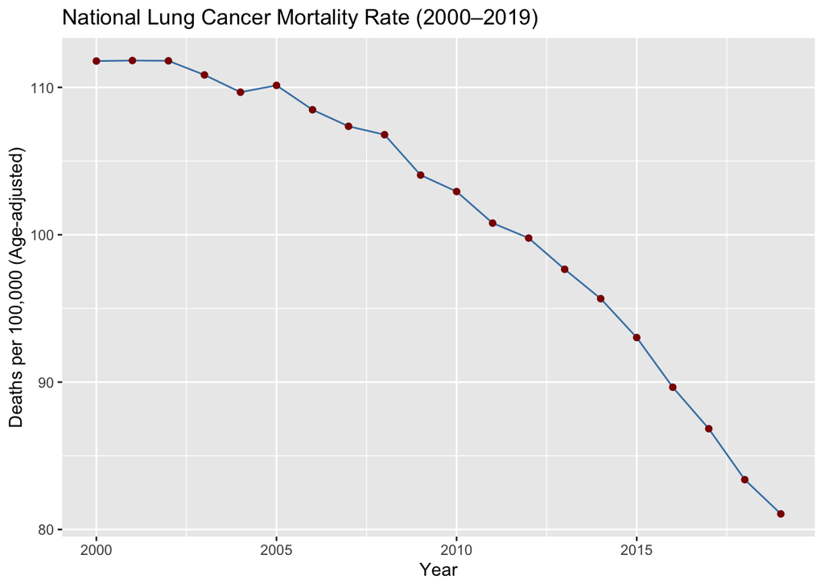

```r
nat_trend <- lung_clean %>%
  group_by(year) %>%
  summarize(mean_rate = mean(mortality_rate, na.rm = TRUE))

ggplot(nat_trend, aes(x = year, y = mean_rate)) +
  geom_line(color = "steelblue") +
  geom_point(color = "darkred") +
  labs(
    title = "National Lung Cancer Mortality Rate (2000–2019)",
    x = "Year",
    y = "Deaths per 100,000 (Age-adjusted)"
  )
```

From this graph, we observe a downward trend of the national mortality rate. The number of death has decreased steadily from ~112 deaths per 100,000 in 2000 to ~82 deaths per 100,000 in 2019. Efforts to increase early-prevention measures such as low-dose computed tomography (LDCT) screenig and better treatments over the past two decades likely contributed to this decline.

Building on the national trend, next we want to examine how mortality rates have differed between men and women over time to assess whether these overall declines have been experienced equally across sexes.

## 2. Mortality Trends By Sex

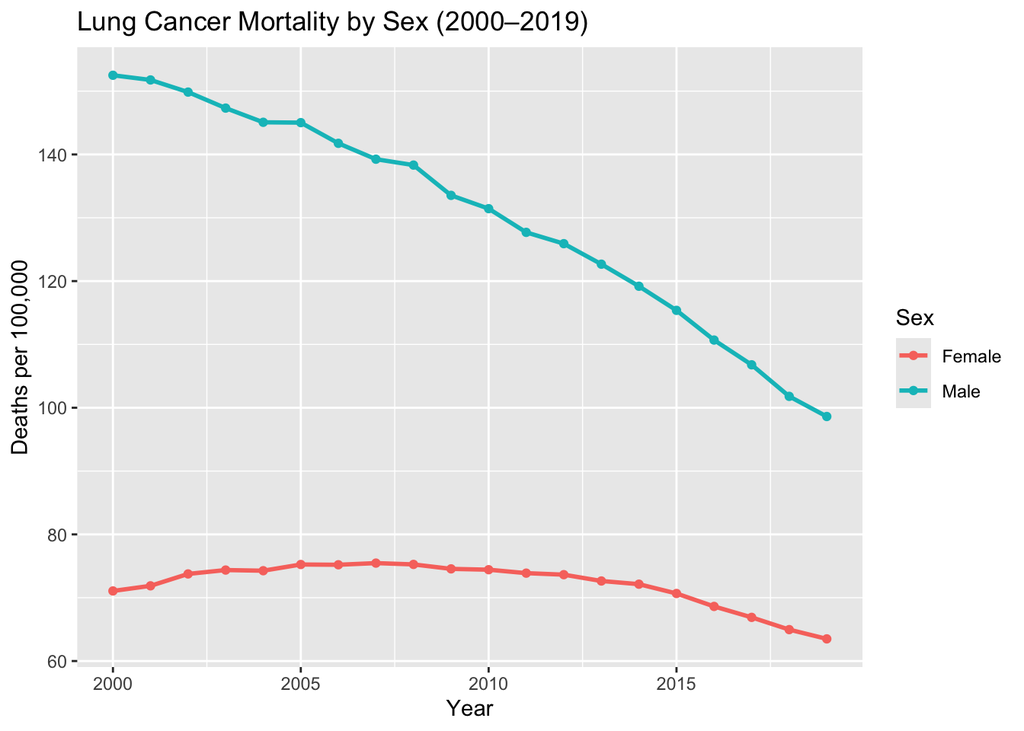

```r
sex_trend <- lung_clean %>%
  group_by(year, sex) %>%
  summarize(rate = mean(mortality_rate, na.rm = TRUE), .groups = "drop")

ggplot(sex_trend, aes(x = year, y = rate, color = sex)) +
  geom_line(linewidth = 1) +
  geom_point() +
  labs(
    title = "Lung Cancer Mortality by Sex (2000–2019)",
    x = "Year",
    y = "Deaths per 100,000",
    color = "Sex"
  )
```

In this graph, we observe that males consistently have higher mortality rates than females, with rates declining from approximately 150 to 100 deaths per 100,000. On the other hand, females experienced a slower decline, with their rates leveling off between 2005 and 2010.

These sex-based differences are likely rooted in historical smoking behavior, as men adopted and abandoned smoking earlier than women. Additionally, early public health messaging often targeted men more aggressively, while female smoking rates rose later in the 20th century and may have plateaued at different times depending on social and cultural factors. The slower decline in female mortality could also point to gaps in screening or treatment access for women in specific age or socioeconomic groups.

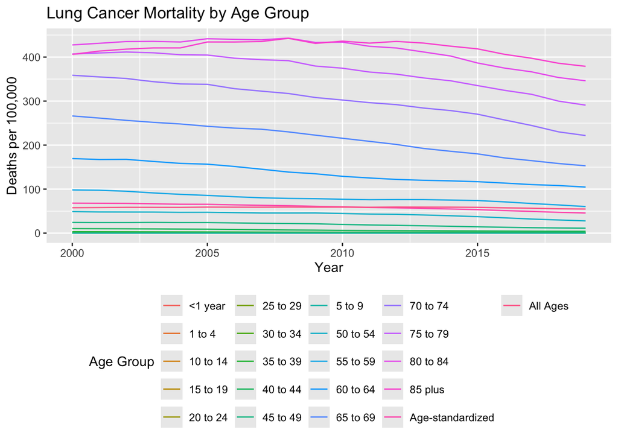

```r
age_trend <- lung_clean %>%
  group_by(year, age_group) %>%
  summarize(mean_rate = mean(mortality_rate, na.rm = TRUE), .groups = "drop")

ggplot(age_trend, aes(x = year, y = mean_rate, color = age_group)) +
  geom_line() +
  labs(
    title = "Lung Cancer Mortality by Age Group",
    x = "Year",
    y = "Deaths per 100,000",
    color = "Age Group"
  ) +
  theme(legend.position = "bottom")
```

Looking at the pink lines, older age groups show significantly higher mortality rates, exceeding 400 deaths per 100,000. In contrast, younger groups (under 50 years) maintain low and nearly flat rates. This indicates that lung cancer predominantly affects older adults, which align with existing studies. The decline observed in older age groups likely reflects improvements in screening and treatment, as well as the cumulative impact of reduced risk factors over time.

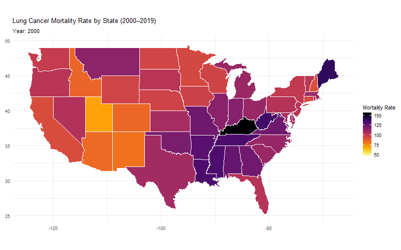

```r
# cannot render the images inside r markdown so i run this in r console and the code shown below is how gif generated
# install.packages("gganimate")
# install.packages("gifski")
# install.packages("viridis")
# install.packages("maps")
# install.packages("tidyverse")
#
#
# library(tidyverse)
# library(gganimate)
# library(gifski)
# library(maps)
# library(viridis)
#
#  1. Prepare state map
# us_states <- map_data("state")
#
#  2.  get valid state names from the map
# valid_states <- unique(us_states$region)
#
#  3. prepare the state name
# lung_anim <- lung_clean %>%
#   mutate(state_lower = tolower(state)) %>%
#   filter(state_lower %in% valid_states) %>%
#   group_by(year, state_lower) %>%
#   summarize(rate = mean(mortality_rate, na.rm = TRUE), .groups = "drop")
#
#  4. join map data with lung data
# map_data_yearly <- left_join(us_states, lung_anim, by = c("region" = "state_lower"))
#
#  5. animated map
# p <- ggplot(map_data_yearly, aes(x = long, y = lat, group = group, fill = rate)) +
#   geom_polygon(color = "white") +
#   coord_fixed(1.3) +
#   scale_fill_viridis(name = "Mortality Rate", option = "inferno", direction = -1) +
#   theme_minimal() +
#   labs(
#     title = "Lung Cancer Mortality Rate by State (2000–2019)",
#     subtitle = "Year: {frame_time}",
#     x = NULL, y = NULL
#   ) +
#   transition_time(year) +
#   ease_aes("linear")
#
#
# anim <- animate(p, nframes = 100, fps = 5, width = 800, height = 500, renderer = gifski_renderer())
# anim_save("lung_mortality.gif", animation = anim)
```